# Day Two

[Andrew Stewart](https://ajstewartlang.netlify.app/)

9th July 2021

# Simple Linear Regression

We’re going to start off by looking at simple linear regression. This is when we have one predictor and one outcome variable. Remember to create a new `.Rproj` file to keep things organised. Once you’ve created that, then you can start with a new script.

## The Packages We Need

First we need to install the packages we need. We’re going to install the `tidyverse` packages plus a few others. The package `Hmisc` allows us to use the `rcorr()` function for calculating Pearson’s r, and the `performance` package so we can test our model assumptions. Remember, if you haven’t previously installed these packages on your laptop you first need to type `install.packages("packagename")` in the console before you can call the `library()` function for that package. You *may* also need to install the package `see` to get the `performance` package working. If so, do that in the console by typing `install.packages("see")`.

```r
library(tidyverse)
library(Hmisc)
library(performance)
```

## Import the Data

Import the dataset called `crime_dataset.csv` - this dataset contains population data, housing price index data and crime data for cities in the US. I’ve stored the data on my website so we can just load it from there.

We can use the function `head()` to display the first few rows of our dataset called “crime”.

```r
crime <- read_csv("https://raw.githubusercontent.com/ajstewartlang/09_glm_regression_pt1/master/data/crime_dataset.csv")
head(crime)
```

```
## # A tibble: 6 x 9
##    Year index_nsa `City, State` Population `Violent Crimes` Homicides Rapes
##   <dbl>     <dbl> <chr>              <dbl>            <dbl>     <dbl> <dbl>
## 1  1975      41.1 Atlanta, GA       490584             8033       185   443
## 2  1975      30.8 Chicago, IL      3150000            37160       818  1657
## 3  1975      36.4 Cleveland, OH     659931            10403       288   491
## 4  1975      20.9 Oakland, CA       337748             5900       111   316
## 5  1975      20.4 Seattle, WA       503500             3971        52   324
## 6    NA      NA   <NA>                  NA               NA        NA    NA
## # … with 2 more variables: Assaults <dbl>, Robberies <dbl>
```

## Tidy the Data

First let’s do some wrangling. There is one column that combines both City and State information. Let’s separate that information out into two new columns called “City” and “State” using the function `separate()`. Then have a look at what you now have. How has the output of `head(crime)` changed from above?

```r
crime <- separate(crime, col = "City, State", into = c("City", "State"))
head(crime)
```

```
## # A tibble: 6 x 10
##    Year index_nsa City      State Population `Violent Crimes` Homicides Rapes
##   <dbl>     <dbl> <chr>     <chr>      <dbl>            <dbl>     <dbl> <dbl>
## 1  1975      41.1 Atlanta   GA        490584             8033       185   443
## 2  1975      30.8 Chicago   IL       3150000            37160       818  1657
## 3  1975      36.4 Cleveland OH        659931            10403       288   491
## 4  1975      20.9 Oakland   CA        337748             5900       111   316
## 5  1975      20.4 Seattle   WA        503500             3971        52   324
## 6    NA      NA   <NA>      <NA>          NA               NA        NA    NA
## # … with 2 more variables: Assaults <dbl>, Robberies <dbl>
```

Now let’s rename the columns to change the name of the “index_nsa” column to “House_price” and get rid of the space in the “Violent Crimes” heading. See how the output of `head(crime)` has changed again?

```r
crime <- crime %>%
  rename(House_price = index_nsa) %>%
  rename(Violent_Crimes = "Violent Crimes")
head(crime)
```

```
## # A tibble: 6 x 10
##    Year House_price City      State Population Violent_Crimes Homicides Rapes
##   <dbl>       <dbl> <chr>     <chr>      <dbl>          <dbl>     <dbl> <dbl>
## 1  1975        41.1 Atlanta   GA        490584           8033       185   443
## 2  1975        30.8 Chicago   IL       3150000          37160       818  1657
## 3  1975        36.4 Cleveland OH        659931          10403       288   491
## 4  1975        20.9 Oakland   CA        337748           5900       111   316
## 5  1975        20.4 Seattle   WA        503500           3971        52   324
## 6    NA        NA   <NA>      <NA>          NA             NA        NA    NA
## # … with 2 more variables: Assaults <dbl>, Robberies <dbl>
```

## Plot the Data

We might first think that as population size increases, crime rate also increases. Let’s first build a scatter plot.

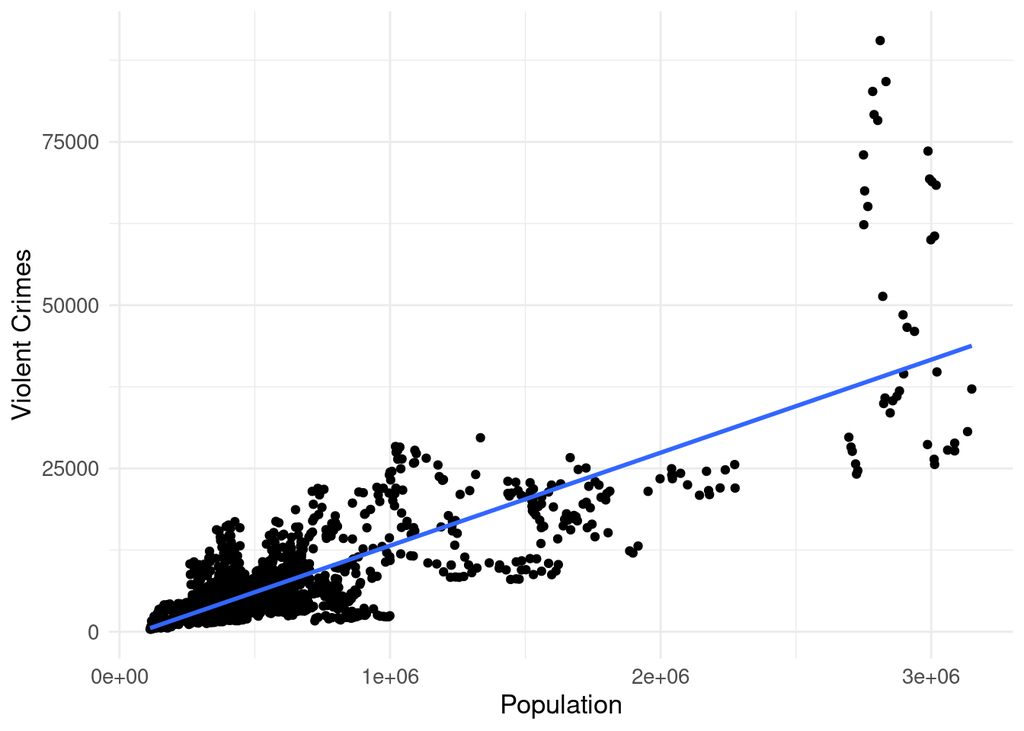

```r
crime %>%
  ggplot(aes(x = Population, y = Violent_Crimes)) +
  geom_point() +
  geom_smooth(method = "lm", se = FALSE) +
  theme_minimal() +
  theme(text = element_text(size = 13)) +
  labs(x = "Population",
       y = "Violent Crimes")
```

## Pearson’s r

This plot looks pretty interesting. How about calculating Pearson’s r?

```r
rcorr(crime$Population, crime$Violent_Crimes)
```

```
##      x    y
## x 1.00 0.81
## y 0.81 1.00
##
## n
##      x    y
## x 1714 1708
## y 1708 1708
##
## P
##   x  y
## x     0
## y  0
```

Look at the r and p-values - r is =.81 and p < .001. So ~64% of the variance in our Violent_Crimes variable is explained by our Population size variable. Clearly there is a positive relationship between population size and the rate of violent crime. From the plot, we might conclude that the relationship is being overly influenced by crime in a small number of very large cities (top right of the plot above). Let’s exclude cities with populations greater than 2,000,000

```r
crime_filtered <- filter(crime, Population < 2000000)
```

Now let’s redo the plot. As there are still likely to be quite a lot of points (and thus overplotting with many points appearing roughly in the same place), we can set the alpha parameter to be < 1 in the `geom_point()` line of code. This parameter corresponds to the translucency of each point. Change it to other values to see what happens.

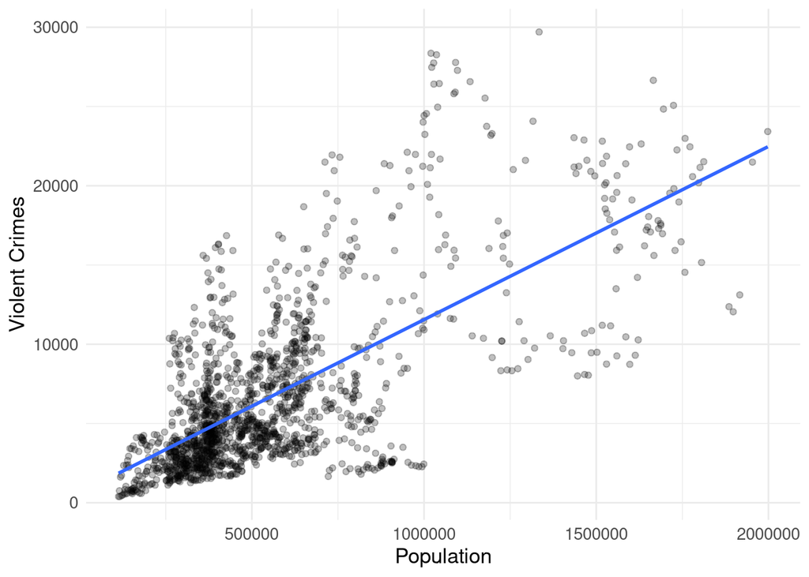

```r
crime_filtered %>%
  ggplot(aes(x = Population, y = Violent_Crimes)) +
  geom_point(alpha = .25) +
  geom_smooth(method = "lm", se = FALSE) +
  theme_minimal() +
  theme(text = element_text(size = 13)) +
  labs(x = "Population",
       y = "Violent Crimes")
```

And calculate Pearson’s r.

```r
rcorr(crime_filtered$Population, crime_filtered$Violent_Crimes)
```

```
##      x    y
## x 1.00 0.69
## y 0.69 1.00
##
## n
##      x    y
## x 1659 1653
## y 1653 1653
##
## P
##   x  y
## x     0
## y  0
```

There is a clear positive relationship (r=.69). Let’s build a linear model.

## Model the Data

Imagine we are a city planner, and we want to know by how much we think violent crimes might increase as a function of population size. In other words, we want to work out how the violent crime rate is predicted by population size.

We’re going to build two linear models - one `model1` where we’re using the mean of our outcome variable as the predictor, and a second `model2` where we are using Population size to predict the Violent Crimes outcome.

```r
model1 <- lm(Violent_Crimes ~ 1, data = crime_filtered)
model2 <- lm(Violent_Crimes ~ Population, data = crime_filtered)
```

## Checking Our Assumptions

Let’s use the `check_model()` function from the performance package to check the assumptions of our model.

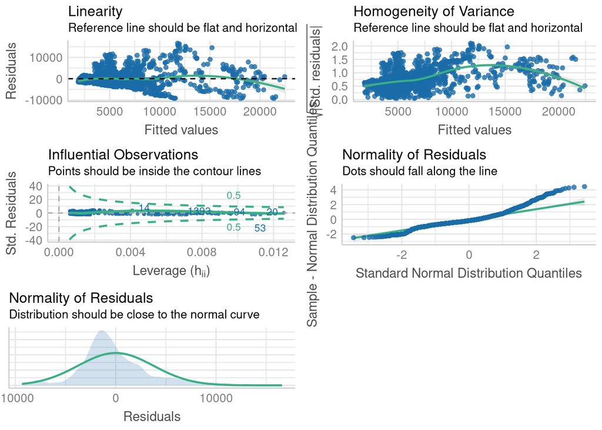

```r
check_model(model2)
```

These look ok. Let’s use the `anova()` function to see if our model with Population as the predictor is better than the one using just the mean.

```r
anova(model1, model2)
```

```
## Analysis of Variance Table
##
## Model 1: Violent_Crimes ~ 1
## Model 2: Violent_Crimes ~ Population
##   Res.Df        RSS Df Sum of Sq      F    Pr(>F)
## 1   1652 4.4192e+10
## 2   1651 2.3373e+10  1 2.082e+10 1470.7 < 2.2e-16 ***
## ---
## Signif. codes:  0 '***' 0.001 '**' 0.01 '*' 0.05 '.' 0.1 ' ' 1
```

It is - the models differ and you’ll see the residual sum of squares (or the error) is less in the second model (which has Population as the predictor). This means the deviation between our observed data and the regression line model `model2` is significantly less than the deviation between our observed data and the mean as a model of our data `model1`. So let’s get the parameter estimates of `model2`.

## Interpreting Our Model

```r
summary(model2)
```

```
##
## Call:
## lm(formula = Violent_Crimes ~ Population, data = crime_filtered)
##
## Residuals:
##     Min      1Q  Median      3Q     Max
## -9350.3 -2083.9  -699.9  1581.6 16585.2
##
## Coefficients:
##              Estimate Std. Error t value Pr(>|t|)
## (Intercept) 6.284e+02  1.827e+02   3.439 0.000598 ***
## Population  1.093e-02  2.849e-04  38.349  < 2e-16 ***
## ---
## Signif. codes:  0 '***' 0.001 '**' 0.01 '*' 0.05 '.' 0.1 ' ' 1
##
## Residual standard error: 3763 on 1651 degrees of freedom
##   (6 observations deleted due to missingness)
## Multiple R-squared:  0.4711, Adjusted R-squared:  0.4708
## F-statistic:  1471 on 1 and 1651 DF,  p-value: < 2.2e-16
```

For a city with a population of about a million, there will be about 11,558 Violent Crimes. We calculate this by multiplying the estimate of our predictor (0.01093) by 1,000,000 and then adding the intercept (628.4).This gives us 11,558.4 crimes - which tallys with what you see in our regression line above.

But wait, can you think of anything wrong with the way we’ve built our model?

## Breakout Rooms

You now have three tasks:  
1. Check whether the same relationship holds for population size and robberies.  
2. Are house prices predicted by the number of violent crimes?  
3. Are house prices predicted by population size?

# Multiple Regression

In standard multiple regression all the predictor variables are entered into the equation and evaluated for their contribution at the same time. Let’s work through a specific example.

An educational psychologist conducted a study that investigated the psycholinguistic variables that contribute to spelling performance in primary school children aged between 7- and 9-years. The researcher presented children with 48 words that varied systematically according to certain features such as age of acquisition, word frequency, word length, and imageability. The psychologist wants to check whether performance on the test accurately reflected children’s spelling ability as estimated by a standardised spelling test. That is, the psychologist wants to check whether her test was appropriate.

Children’s chronological age (in months) `(age)`, their reading age `(RA)`, their standardised reading age `(std_RA)`, and their standardised spelling score `(std_SPELL)` were chosen as predictors. The outcome variable was the percentage correct spelling `(corr_spell)` score attained by each child using the list of 48 words.

First we need to load the packages we need - the require function assumes they are already on your machine. If they are not, then you need to `install.packages ("packagename")` first:

## The Packages We Need

In addition to the packages we used earlier, we also need the following: `{MASS}`, `{car}`, and `{olsrr}`.

```r
library(MASS) # Needed for maths functions
library(car) # Needed for VIF calculation
```

## Import the Data

You now need to read in the data file from my website.

```r
MRes_tut2 <- read_csv("https://raw.githubusercontent.com/ajstewartlang/10_glm_regression_pt2/master/data/MRes_tut2.csv")
```

### Examining Possible Relationships

Before we start, let’s look at the relationships between our IVs (predictors) and our DV (outcome). We can plot graphs depicting the correlations. We’ll plot test performance against each of our four predictors in turn:

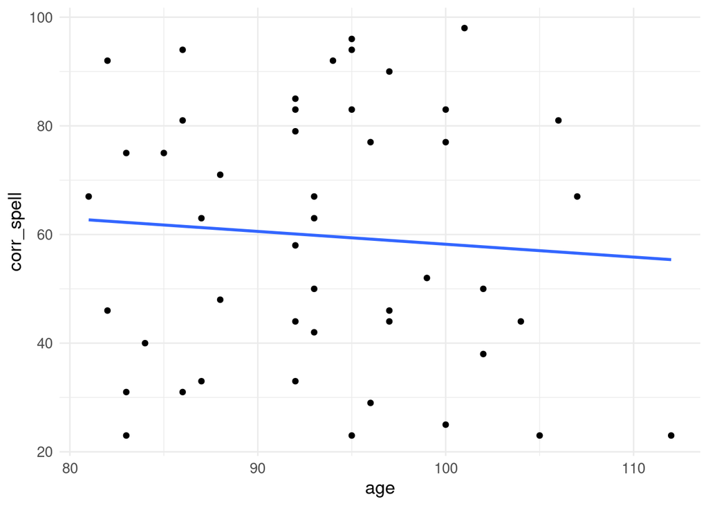

```r
ggplot(MRes_tut2, aes(x = age, y = corr_spell)) +
  geom_point() +
  geom_smooth(method = "lm", se = FALSE) +
  theme_minimal() +
  theme(text = element_text(size = 13))
```

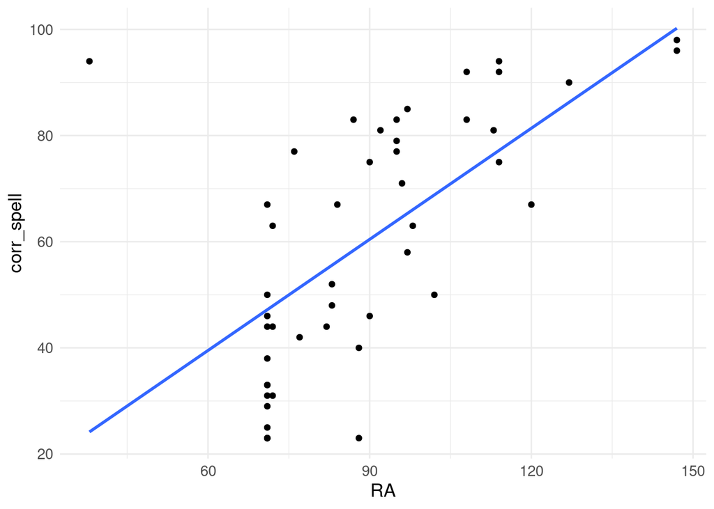

```r
ggplot(MRes_tut2, aes(x = RA, y = corr_spell)) +
  geom_point() +
  geom_smooth(method = "lm", se = FALSE) +
  theme_minimal() +
  theme(text = element_text(size = 13))
```

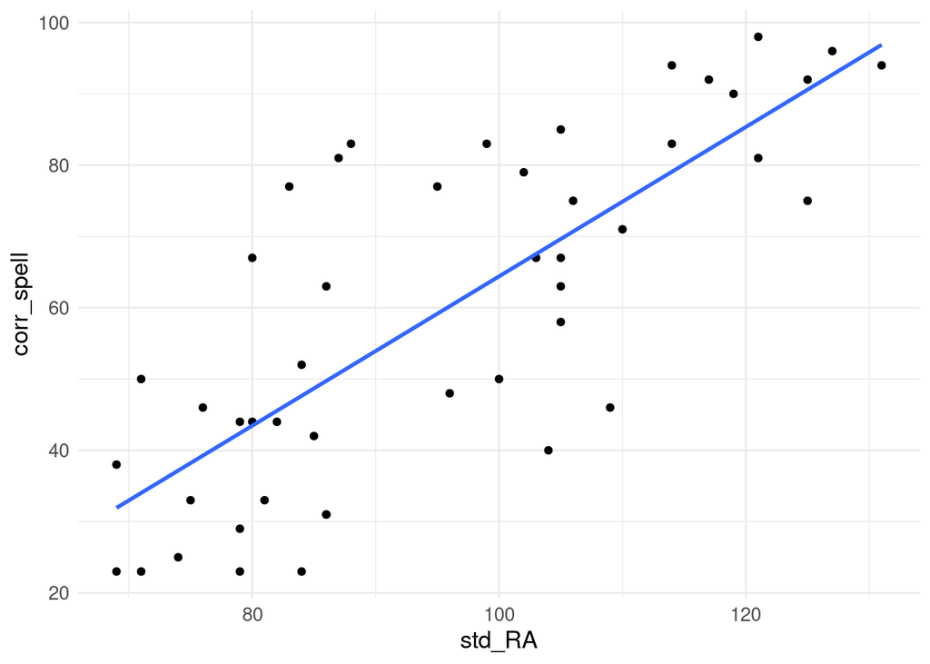

```r
ggplot(MRes_tut2, aes(x = std_RA, y = corr_spell)) +
  geom_point() +
  geom_smooth(method = "lm", se = FALSE) +
  theme_minimal() +
  theme(text = element_text(size = 13))
```

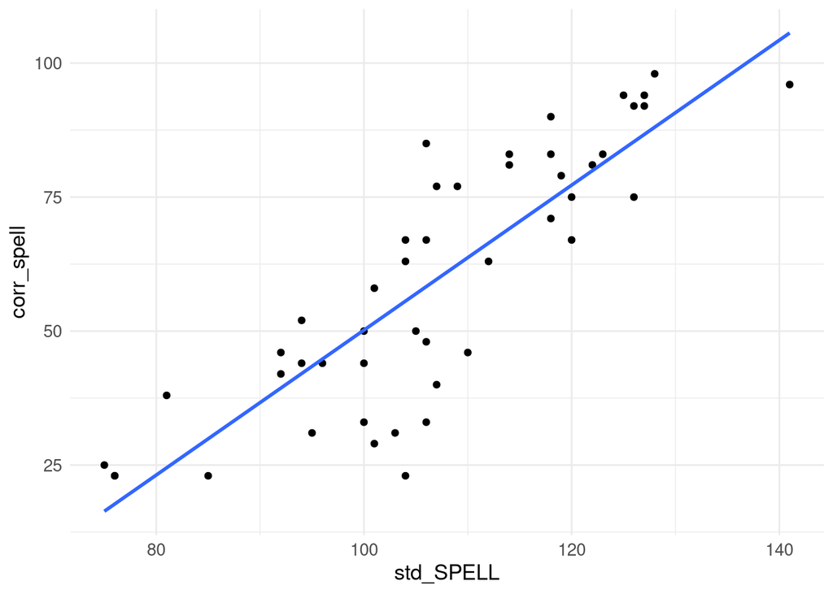

```r
ggplot(MRes_tut2, aes(x = std_SPELL, y = corr_spell)) +
  geom_point() +
  geom_smooth(method = "lm", se = FALSE) +
  theme_minimal() +
  theme(text = element_text(size = 13))
```

## Model the Data

We’ll build one model (which we’ll call `model0`) that is the mean of our outcome variable, and another model (`model1`) which contains all our predictors:

```r
model0 <- lm(corr_spell ~ 1, data = MRes_tut2)
model1 <- lm(corr_spell ~ age + RA + std_RA + std_SPELL, data = MRes_tut2)
```

Let’s compare them to each other:

```r
anova(model0, model1)
```

```
## Analysis of Variance Table
##
## Model 1: corr_spell ~ 1
## Model 2: corr_spell ~ age + RA + std_RA + std_SPELL
##   Res.Df     RSS Df Sum of Sq      F    Pr(>F)
## 1     46 26348.4
## 2     42  3901.1  4     22447 60.417 < 2.2e-16 ***
## ---
## Signif. codes:  0 '***' 0.001 '**' 0.01 '*' 0.05 '.' 0.1 ' ' 1
```

We see that the models differ from each other (look a the *p*-value of the comparison) and that the model with the four predictors has the lower Residuals (RSS) value meaning there is less error between the model and the observed data relative to the simpler intercept-only model (i.e., the mean) and the observed data.

### Checking our Assumptions

OK, so they differ - now let’s plot information about our model assumptions - remember, we are particularly interested in Cook’s distance values for our case…

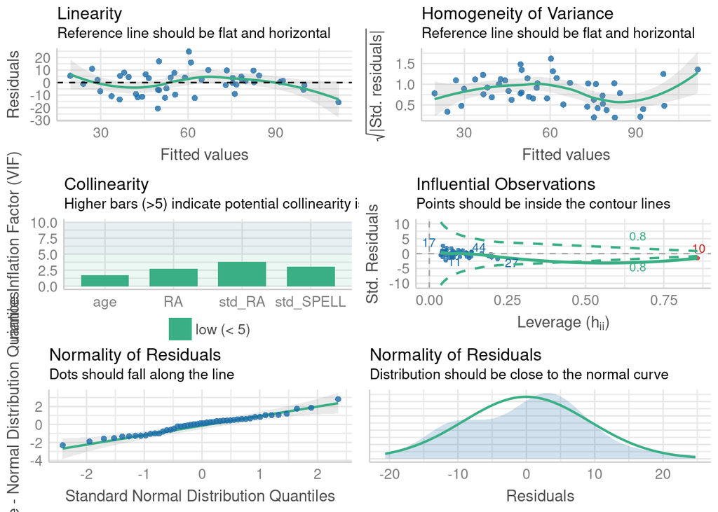

```r
check_model(model1)
```

The errors looks fairly equally distributed along our fitted values (homoscedasticity) - although a little worse for high fitted values - and from the Q-Q plot we can tell they look fairly normal (they should follow the diagonal). How about influential cases? So, Case 10 looks a bit dodgy - it has a high Cook’s Distance value - which suggests it is having a disproportionate effect on our model. Let’s exclude it using the `filter()` function - the symbol `!=` means ‘does not equal’ so we are selecting values other than Case 10.

### Dropping an Influential Case

```r
MRes_tut2_drop10 <- filter(MRes_tut2, case != "10")
```

### Re(model) the Data

We now create another model (`model2`) which doesn’t include Case 10.

```r
model2 <- lm(corr_spell ~ age + RA + std_RA + std_SPELL, data = MRes_tut2_drop10)
```

Let’s check the model assumptions again using `check_model()`.

### Checking our Assumptions

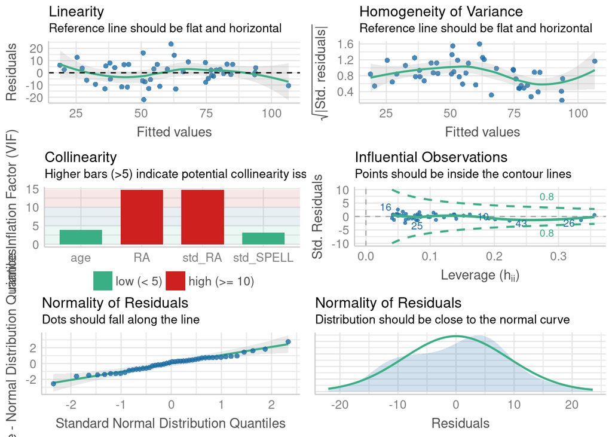

```r
check_model(model2)
```

Now, let’s look at the multicollinearity values measured by VIF:

```r
vif(model2)
```

```
##       age        RA    std_RA std_SPELL
##  3.843462 14.763168 14.672084  3.140457
```

It looks like RA and std_RA are problematic. We can look at the correlation between them using the `rcorr()` function:

```r
rcorr(MRes_tut2_drop10$RA, MRes_tut2_drop10$std_RA)
```

```
##      x    y
## x 1.00 0.88
## y 0.88 1.00
##
## n= 46
##
##
## P
##   x  y
## x     0
## y  0
```

### Re(model) the Data

The correlation is pretty high (0.88), so let’s exclude the predictor with the highest VIF value (which is RA) and build a new model:

```r
model3 <- lm(corr_spell ~ age + std_RA + std_SPELL, data = MRes_tut2_drop10)
vif(model3)
```

```
##       age    std_RA std_SPELL
##  1.190827  2.636186  2.821235
```

### Checking our Assumptions

These values look ok now. Let’s check the model assumptions again.

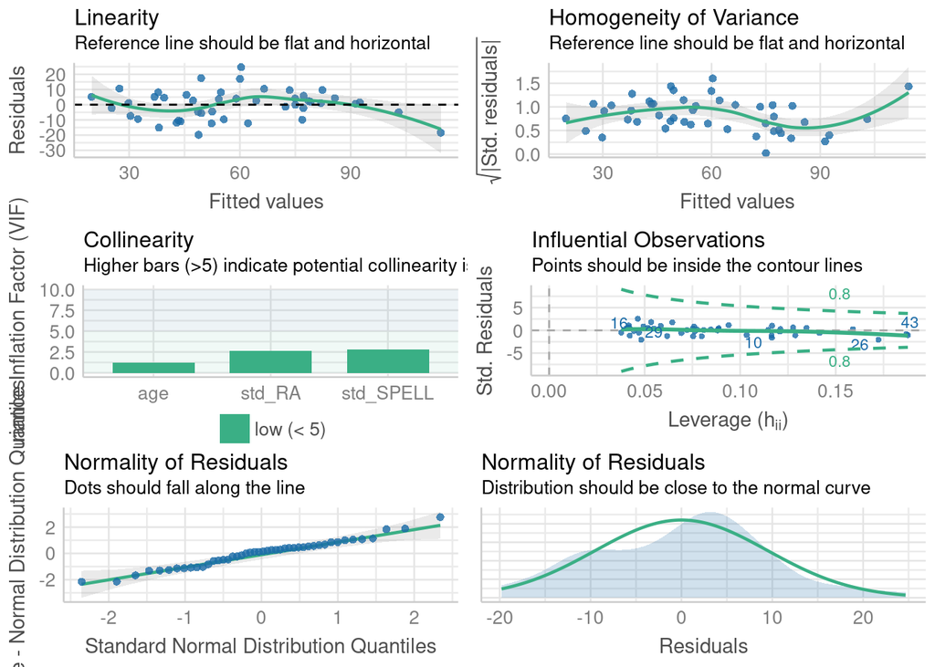

```r
check_model(model3)
```

### Summary of our Model

Now let’s generate the coefficients as this looks like a sensible model.

```r
summary(model3)
```

```
##
## Call:
## lm(formula = corr_spell ~ age + std_RA + std_SPELL, data = MRes_tut2_drop10)
##
## Residuals:
##     Min      1Q  Median      3Q     Max
## -19.801  -6.907   1.327   5.155  24.669
##
## Coefficients:
##              Estimate Std. Error t value Pr(>|t|)
## (Intercept) -209.4400    26.7210  -7.838 9.43e-10 ***
## age            1.1033     0.2133   5.172 6.09e-06 ***
## std_RA         0.3804     0.1385   2.747  0.00883 **
## std_SPELL      1.2107     0.1650   7.339 4.78e-09 ***
## ---
## Signif. codes:  0 '***' 0.001 '**' 0.01 '*' 0.05 '.' 0.1 ' ' 1
##
## Residual standard error: 9.824 on 42 degrees of freedom
## Multiple R-squared:  0.8388, Adjusted R-squared:  0.8273
## F-statistic: 72.87 on 3 and 42 DF,  p-value: < 2.2e-16
```

```r
model0 <- lm(corr_spell ~ 1, data = MRes_tut2_drop10)
anova(model3, model0)
```

```
## Analysis of Variance Table
##
## Model 1: corr_spell ~ age + std_RA + std_SPELL
## Model 2: corr_spell ~ 1
##   Res.Df     RSS Df Sum of Sq      F    Pr(>F)
## 1     42  4053.5
## 2     45 25151.0 -3    -21098 72.866 < 2.2e-16 ***
## ---
## Signif. codes:  0 '***' 0.001 '**' 0.01 '*' 0.05 '.' 0.1 ' ' 1
```

We’d write our equation as something like:

`Spelled correct = -209.44 + 1.10(age) + 0.38(std_RA) + 1.21(std_SPELL) + residual`

# Stepwise regression

We can also do stepwise regression - forwards is when you start with the null model and predictors are added until they don’t explain any more variance, backwards is when you start with the full model and remove predictors until removal starts affecting your model’s predictive ability. Let’s keep case 10 dropped and also drop the high VIF predictor (RA). This is handy for models with lots of predictors where the order in sequential regression is not obvious.

## Model the Data

```r
model0 <- lm(corr_spell ~ 1, data = MRes_tut2_drop10)
model1 <- lm(corr_spell ~ age + std_RA + std_SPELL, data = MRes_tut2_drop10)
```

Let’s do stepwise forwards:

```r
steplimitsf <- step(model0, scope = list (lower = model0, upper = model1), direction = "forward")
```

```
## Start:  AIC=291.98
## corr_spell ~ 1
##
##             Df Sum of Sq     RSS    AIC
## + std_SPELL  1   17802.2  7348.8 237.39
## + std_RA     1   14780.1 10370.9 253.23
## <none>                   25151.0 291.98
## + age        1      48.7 25102.3 293.89
##
## Step:  AIC=237.39
## corr_spell ~ std_SPELL
##
##          Df Sum of Sq    RSS    AIC
## + age     1   2567.20 4781.6 219.62
## + std_RA  1    714.14 6634.7 234.69
## <none>                7348.8 237.39
##
## Step:  AIC=219.62
## corr_spell ~ std_SPELL + age
##
##          Df Sum of Sq    RSS    AIC
## + std_RA  1     728.1 4053.5 214.02
## <none>                4781.6 219.62
##
## Step:  AIC=214.02
## corr_spell ~ std_SPELL + age + std_RA
```

```r
summary(steplimitsf)
```

```
##
## Call:
## lm(formula = corr_spell ~ std_SPELL + age + std_RA, data = MRes_tut2_drop10)
##
## Residuals:
##     Min      1Q  Median      3Q     Max
## -19.801  -6.907   1.327   5.155  24.669
##
## Coefficients:
##              Estimate Std. Error t value Pr(>|t|)
## (Intercept) -209.4400    26.7210  -7.838 9.43e-10 ***
## std_SPELL      1.2107     0.1650   7.339 4.78e-09 ***
## age            1.1033     0.2133   5.172 6.09e-06 ***
## std_RA         0.3804     0.1385   2.747  0.00883 **
## ---
## Signif. codes:  0 '***' 0.001 '**' 0.01 '*' 0.05 '.' 0.1 ' ' 1
##
## Residual standard error: 9.824 on 42 degrees of freedom
## Multiple R-squared:  0.8388, Adjusted R-squared:  0.8273
## F-statistic: 72.87 on 3 and 42 DF,  p-value: < 2.2e-16
```

Stepwise backwards:

```r
steplimitsb <- step(model1, direction = "back")
```

```
## Start:  AIC=214.02
## corr_spell ~ age + std_RA + std_SPELL
##
##             Df Sum of Sq    RSS    AIC
## <none>                   4053.5 214.02
## - std_RA     1     728.1 4781.6 219.62
## - age        1    2581.2 6634.7 234.69
## - std_SPELL  1    5198.3 9251.8 249.98
```

```r
summary(steplimitsb)
```

```
##
## Call:
## lm(formula = corr_spell ~ age + std_RA + std_SPELL, data = MRes_tut2_drop10)
##
## Residuals:
##     Min      1Q  Median      3Q     Max
## -19.801  -6.907   1.327   5.155  24.669
##
## Coefficients:
##              Estimate Std. Error t value Pr(>|t|)
## (Intercept) -209.4400    26.7210  -7.838 9.43e-10 ***
## age            1.1033     0.2133   5.172 6.09e-06 ***
## std_RA         0.3804     0.1385   2.747  0.00883 **
## std_SPELL      1.2107     0.1650   7.339 4.78e-09 ***
## ---
## Signif. codes:  0 '***' 0.001 '**' 0.01 '*' 0.05 '.' 0.1 ' ' 1
##
## Residual standard error: 9.824 on 42 degrees of freedom
## Multiple R-squared:  0.8388, Adjusted R-squared:  0.8273
## F-statistic: 72.87 on 3 and 42 DF,  p-value: < 2.2e-16
```

And stepwise using both forwards and backwards procedures:

```r
steplimitsboth <- step(model0, scope = list (upper = model1), direction = "both")
```

```
## Start:  AIC=291.98
## corr_spell ~ 1
##
##             Df Sum of Sq     RSS    AIC
## + std_SPELL  1   17802.2  7348.8 237.39
## + std_RA     1   14780.1 10370.9 253.23
## <none>                   25151.0 291.98
## + age        1      48.7 25102.3 293.89
##
## Step:  AIC=237.39
## corr_spell ~ std_SPELL
##
##             Df Sum of Sq     RSS    AIC
## + age        1    2567.2  4781.6 219.62
## + std_RA     1     714.1  6634.7 234.69
## <none>                    7348.8 237.39
## - std_SPELL  1   17802.2 25151.0 291.98
##
## Step:  AIC=219.62
## corr_spell ~ std_SPELL + age
##
##             Df Sum of Sq     RSS    AIC
## + std_RA     1     728.1  4053.5 214.02
## <none>                    4781.6 219.62
## - age        1    2567.2  7348.8 237.39
## - std_SPELL  1   20320.7 25102.3 293.89
##
## Step:  AIC=214.02
## corr_spell ~ std_SPELL + age + std_RA
##
##             Df Sum of Sq    RSS    AIC
## <none>                   4053.5 214.02
## - std_RA     1     728.1 4781.6 219.62
## - age        1    2581.2 6634.7 234.69
## - std_SPELL  1    5198.3 9251.8 249.98
```

### Checking our Assumptions

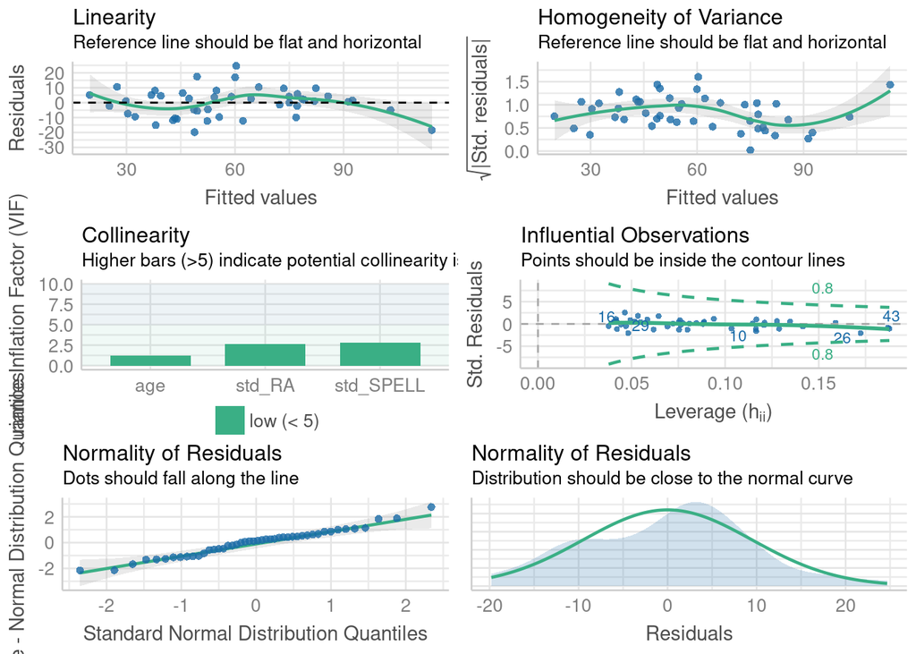

```r
check_model(steplimitsboth)
```

These look ok.

```r
summary(steplimitsboth)
```

```
##
## Call:
## lm(formula = corr_spell ~ std_SPELL + age + std_RA, data = MRes_tut2_drop10)
##
## Residuals:
##     Min      1Q  Median      3Q     Max
## -19.801  -6.907   1.327   5.155  24.669
##
## Coefficients:
##              Estimate Std. Error t value Pr(>|t|)
## (Intercept) -209.4400    26.7210  -7.838 9.43e-10 ***
## std_SPELL      1.2107     0.1650   7.339 4.78e-09 ***
## age            1.1033     0.2133   5.172 6.09e-06 ***
## std_RA         0.3804     0.1385   2.747  0.00883 **
## ---
## Signif. codes:  0 '***' 0.001 '**' 0.01 '*' 0.05 '.' 0.1 ' ' 1
##
## Residual standard error: 9.824 on 42 degrees of freedom
## Multiple R-squared:  0.8388, Adjusted R-squared:  0.8273
## F-statistic: 72.87 on 3 and 42 DF,  p-value: < 2.2e-16
```

You’ll see that the same final model is arrived it in each case. We have three significant predictors.

## Breakout Rooms

Using the `crime_filtered` dataset from earlier, I would like you to build the appropriate regression model where house prices are predicted by Population, Robberies, and Assaults in the year 2000 (note that you will need to filter the `crime_filtered` dataset in order to select only the year 2000).

# ANOVA

## Loading our Packages

First of all, we need to load the three packages we will be using - they are `tidyverse`, `afex`, and `emmeans`. The `{afex}` package is the one we use for conducting ANOVA. We use the `{emmeans}` package for running follow-up tests on the ANOVA model that we will be building.

```r
library(tidyverse)
library(afex)
library(emmeans)
```

## One-way ANOVA

We have 45 participants in a between participants design where we are interested in the effect of beverage consumed on ability on a motor task. Our experimental factor (beverage type) has 3 levels. These are Water vs. Single Espresso vs. Double Espresso, and Ability is our DV measured on a continuous scale. Let’s read in our data.

### Reading in our Data

```r
my_data <- read_csv("https://raw.githubusercontent.com/ajstewartlang/11_glm_anova_pt1/master/data/cond.csv")
head(my_data)
```

```
## # A tibble: 6 x 3
##   Participant Condition Ability
##         <dbl> <chr>       <dbl>
## 1           1 Water        4.82
## 2           2 Water        5.41
## 3           3 Water        5.73
## 4           4 Water        4.36
## 5           5 Water        5.47
## 6           6 Water        5.50
```

We see that we have three variables, but our experimental variable `Condition` is not coded as a factor. Let’s fix that…

```r
my_data_tidied <- my_data %>%
  mutate(Condition = factor(Condition))
head(my_data_tidied)
```

```
## # A tibble: 6 x 3
##   Participant Condition Ability
##         <dbl> <fct>       <dbl>
## 1           1 Water        4.82
## 2           2 Water        5.41
## 3           3 Water        5.73
## 4           4 Water        4.36
## 5           5 Water        5.47
## 6           6 Water        5.50
```

### Summarising our Data

Let’s work our some summary statistics and build a data visualisation next.

```r
my_data_tidied %>%
  group_by(Condition) %>%
  summarise(mean = mean(Ability),
            sd = sd(Ability))
```

```
## # A tibble: 3 x 3
##   Condition        mean    sd
##   <fct>           <dbl> <dbl>
## 1 Double Espresso  8.89 0.467
## 2 Single Espresso  6.99 0.419
## 3 Water            5.17 0.362
```

### Visualising our Data

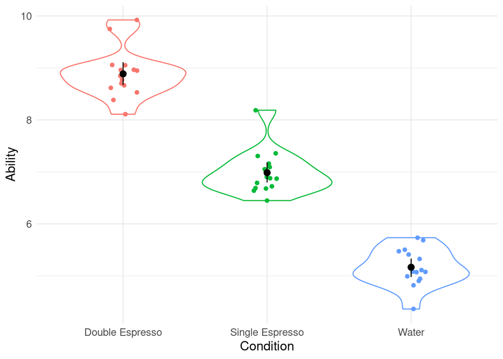

```r
set.seed(1234)
my_data_tidied %>%
  ggplot(aes(x = Condition, y = Ability, colour = Condition)) +
  geom_violin() +
  geom_jitter(width = .1) +
  guides(colour = FALSE) +
  stat_summary(fun.data = "mean_cl_boot", colour = "black") +
  theme_minimal() +
  theme(text = element_text(size = 13))
```

We have built a visualisation where we have plotted the raw data points using the `geom_jitter()` function, and the shape of the distribution for each condition using the `geom_violin()` function. We have also added some summary data in the form of the Mean and Confidence Intervals around the Mean using the `stat_summary()` function. The `set.seed()` parameter ensures the random noise added to our jittered points is reproducible.

### Building our ANOVA Model

Let’s now build our model using the `aov_4()` function in the `{afex}` package. The syntax for ANOVA models in `aov_4()` is: `aov_4(DV ~ IV + (1 | Participant), data = my_data_tidied)`. The `~` symbol means predicted by, the `(1 | Participant)` term corresponds to our random effect - we obviously can’t test all the participants in the world so have taken just a random sample from this population. Finally, we need to specify what dataset we are using by making that clear in the `data = my_data_tidied` bit of the model. We are going to map the output of the `aov()` function onto a variable I’m calling `model`. This means that the ANOVA results will be stored in this variable and will allow us to access them later.

```r
model <- aov_4(Ability ~ Condition + (1 | Participant), data = my_data_tidied)
```

To get the output of the ANOVA, we can use the `summary()` function with our newly created `model`.

### Interpreting the Model Output

```r
summary(model)
```

```
## Anova Table (Type 3 tests)
##
## Response: Ability
##           num Df den Df     MSE      F     ges    Pr(>F)
## Condition      2     42 0.17484 297.05 0.93397 < 2.2e-16 ***
## ---
## Signif. codes:  0 '***' 0.001 '**' 0.01 '*' 0.05 '.' 0.1 ' ' 1
```

The effect size (ges) is generalised eta squared and for designs with more than one factor it can be a useful indicator of how much variance in the dependent variable can be explained by each factor (plus any interactions between factors).

So, we there is an effect in our model - the F-value is pretty big and the *p*-value pretty small) but we can’t know what’s driving the difference yet. We need to run some pairwise comparisons using the `emmeans()` function to tell us what mean(s) differ(s) from what other mean(s).

```r
emmeans(model, pairwise ~ Condition)
```

```
## $emmeans
##  Condition       emmean    SE df lower.CL upper.CL
##  Double Espresso   8.89 0.108 42     8.67     9.10
##  Single Espresso   6.99 0.108 42     6.77     7.20
##  Water             5.17 0.108 42     4.95     5.38
##
## Confidence level used: 0.95
##
## $contrasts
##  contrast                          estimate    SE df t.ratio p.value
##  Double Espresso - Single Espresso     1.90 0.153 42 12.453  <.0001
##  Double Espresso - Water               3.72 0.153 42 24.372  <.0001
##  Single Espresso - Water               1.82 0.153 42 11.920  <.0001
##
## P value adjustment: tukey method for comparing a family of 3 estimates
```

Note that the default adjustment for multiple comparisons is Tukey’s. We can change that by adding an extra parameter to our model such as `adjust = "bonferonni"`. In this case, it doesn’t make any difference to our comparisons.

```r
emmeans(model, pairwise ~ Condition, adjust = "bonferroni")
```

```
## $emmeans
##  Condition       emmean    SE df lower.CL upper.CL
##  Double Espresso   8.89 0.108 42     8.67     9.10
##  Single Espresso   6.99 0.108 42     6.77     7.20
##  Water             5.17 0.108 42     4.95     5.38
##
## Confidence level used: 0.95
##
## $contrasts
##  contrast                          estimate    SE df t.ratio p.value
##  Double Espresso - Single Espresso     1.90 0.153 42 12.453  <.0001
##  Double Espresso - Water               3.72 0.153 42 24.372  <.0001
##  Single Espresso - Water               1.82 0.153 42 11.920  <.0001
##
## P value adjustment: bonferroni method for 3 tests
```

We found a significant effect of Beverage type (F (2,42) = 297.05, *p* < .001, generalised η2 = .93). Tukey comparisons revealed that the Water group performed significantly worse than the Single Espresso Group (*p* < .001), that the Water group performed significantly worse than the Double Espresso Group (*p* < .001), and that the Single Espresso Group performed significantly worse than the Double Espresso Group (*p* < .001).

In other words, drinking some coffee improves motor performance relative to drinking water, and drinking a lot of coffee improves motor performance even more.

## Repeated Measures ANOVA

Let’s imagine we have an experiment where we asked 32 participants to learn how to pronounce words of differing levels of complexity - Very Easy, Easy, Hard, and Very Hard. They were presented with these words in an initial exposure phase. After a 30 minute break we tested participants by asking them to say the words out loud when they appeared on a computer screen. We recorded their times in seconds. We want to know whether there is a difference in their response times for each level of word complexity.

### Reading in our Data

First we read in the data.

```r
rm_data <- read_csv("https://raw.githubusercontent.com/ajstewartlang/11_glm_anova_pt1/master/data/rm_data.csv")
head(rm_data)
```

```
## # A tibble: 6 x 3
##   Participant Condition    RT
##         <dbl> <chr>     <dbl>
## 1           1 Very Easy  1.25
## 2           2 Very Easy  1.16
## 3           3 Very Easy  1.12
## 4           4 Very Easy  1.33
## 5           5 Very Easy  1.16
## 6           6 Very Easy  1.15
```

We can see from the `head()` function that Condition isn’t yet coded as a factor. Let’s fix that.

```r
rm_data_tidied <- rm_data %>%
  mutate(Condition = factor(Condition))
head(rm_data_tidied)
```

```
## # A tibble: 6 x 3
##   Participant Condition    RT
##         <dbl> <fct>     <dbl>
## 1           1 Very Easy  1.25
## 2           2 Very Easy  1.16
## 3           3 Very Easy  1.12
## 4           4 Very Easy  1.33
## 5           5 Very Easy  1.16
## 6           6 Very Easy  1.15
```

### Summarising our Data

Let’s generate the Mean and Standard Deviation for each of our four conditions.

```r
rm_data_tidied %>%
  group_by(Condition) %>%
  summarise(mean = mean(RT), sd = sd (RT))
```

```
## # A tibble: 4 x 3
##   Condition  mean     sd
##   <fct>     <dbl>  <dbl>
## 1 Easy       1.23 0.0610
## 2 Hard       1.39 0.118
## 3 Very Easy  1.20 0.0511
## 4 Very Hard  1.87 0.187
```

### Visualising our Data

And visualise the data - note here that I am using the `fct_reorder()` function to reorder the levels of our factor based on the RT. This can be useful to make our viusalisations more easily interpretable.

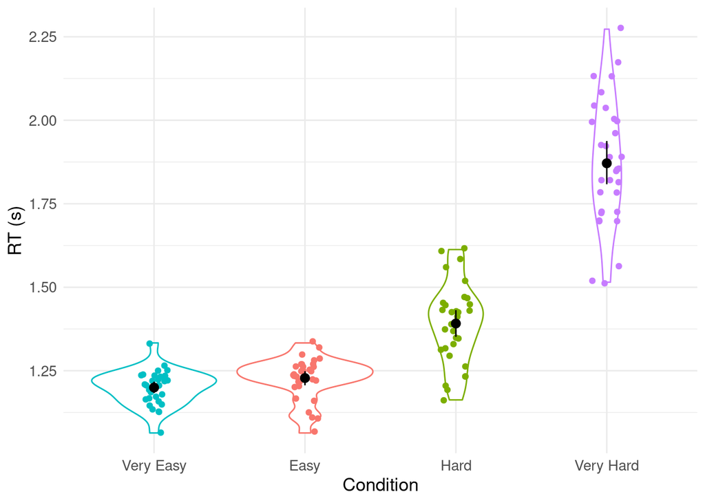

```r
rm_data_tidied %>%
  ggplot(aes(x = fct_reorder(Condition, RT), y = RT, colour = Condition)) +
  geom_violin() +
  geom_jitter(width = .1) +
  guides(colour = FALSE) +
  stat_summary(fun.data = "mean_cl_boot", colour = "black") +
  theme_minimal() +
  theme(text = element_text(size = 13)) +
  labs(x = "Condition", y = "RT (s)")
```

### Building our ANOVA Model

We build our ANOVA model in a similar way as we did previously. Except in this case our random effect we define as `(1 + Condition | Participant)`. In order to capture the fact that our `Condition` is a repeated measures factor, we add it to the random effect term like this.

```r
rm_model <- aov_4(RT ~ Condition + (1 + Condition | Participant), data = rm_data_tidied)
```

### Interpreting the Model Output

We extract the summary of our model in the same way we did for the between participants ANOVA.

```r
summary(rm_model)
```

```
##
## Univariate Type III Repeated-Measures ANOVA Assuming Sphericity
##
##             Sum Sq num Df Error SS den Df  F value    Pr(>F)
## (Intercept) 259.07      1  0.50313     31 15962.33 < 2.2e-16 ***
## Condition     9.27      3  1.20624     93   238.23 < 2.2e-16 ***
## ---
## Signif. codes:  0 '***' 0.001 '**' 0.01 '*' 0.05 '.' 0.1 ' ' 1
##
##
## Mauchly Tests for Sphericity
##
##           Test statistic    p-value
## Condition        0.38404 3.0211e-05
##
##
## Greenhouse-Geisser and Huynh-Feldt Corrections
##  for Departure from Sphericity
##
##            GG eps Pr(>F[GG])
## Condition 0.65596  < 2.2e-16 ***
## ---
## Signif. codes:  0 '***' 0.001 '**' 0.01 '*' 0.05 '.' 0.1 ' ' 1
##
##              HF eps   Pr(>F[HF])
## Condition 0.7000534 3.359493e-31
```

With this option, we didn’t get the effect size measure in our measure. We can generate that though by asking for our model to be presented in anova format using the `anova()` function.

```r
anova(rm_model)
```

```
## Anova Table (Type 3 tests)
##
## Response: RT
##           num Df den Df      MSE      F     ges    Pr(>F)
## Condition 1.9679 61.004 0.019773 238.23 0.84431 < 2.2e-16 ***
## ---
## Signif. codes:  0 '***' 0.001 '**' 0.01 '*' 0.05 '.' 0.1 ' ' 1
```

The effect size is measured by ges and is the recommended effect size measure for repeated measures designs (Bakeman, 2005). Note the dfs in this output are always corrected as if there is a violation of sphericity (violated when the variances of the differences between all possible pairs of within-subject conditions (i.e., levels of the independent variable) are **not** equal) - to be conservative (and to avoid Type I errors) we might be better off to always choose these corrected dfs.

From this, we can see we have effect of Condition. But we don’t know where the differences lie between the different levels of our factor. So we use the `emmeans()` function to find that out. Here we will be using the Bonferroni correction for multiple comparisons.

```r
emmeans(rm_model, pairwise ~ Condition, adjust = "Bonferroni")
```

```
## $emmeans
##  Condition emmean     SE  df lower.CL upper.CL
##  Easy        1.23 0.0208 123     1.19     1.27
##  Hard        1.39 0.0208 123     1.35     1.43
##  Very.Easy   1.20 0.0208 123     1.16     1.24
##  Very.Hard   1.87 0.0208 123     1.83     1.91
##
## Warning: EMMs are biased unless design is perfectly balanced
## Confidence level used: 0.95
##
## $contrasts
##  contrast              estimate     SE df t.ratio p.value
##  Easy - Hard            -0.1633 0.0285 93  -5.735 <.0001
##  Easy - Very.Easy        0.0285 0.0285 93   1.000 1.0000
##  Easy - Very.Hard       -0.6430 0.0285 93 -22.584 <.0001
##  Hard - Very.Easy        0.1917 0.0285 93   6.734 <.0001
##  Hard - Very.Hard       -0.4797 0.0285 93 -16.849 <.0001
##  Very.Easy - Very.Hard  -0.6715 0.0285 93 -23.584 <.0001
##
## P value adjustment: bonferroni method for 6 tests
```

From the above we can see that all conditions differ from all other conditions, *apart* from the Easy vs. Very Easy comparison which is not significant.

## Factorial ANOVA

Imagine the case where we’re interested in the effect of positive vs. negative contexts on how quickly (in milliseconds) people respond to positive vs. negative sentences. We think there might be a priming effect (i.e., people are quicker to respond to positive sentences after positive contexts vs. after negative contexts - and vice versa). So, we have two factors, each with two levels. This is what’s known as a full factorial design where every subject participates in every condition. In the following experiment we have 60 participants.

### Reading in our Data

```r
factorial_data <- read_csv("https://raw.githubusercontent.com/ajstewartlang/11_glm_anova_pt1/master/data/factorial_data.csv")
head(factorial_data)
```

```
## # A tibble: 6 x 5
##   Subject  Item    RT Sentence Context
##     <dbl> <dbl> <dbl> <chr>    <chr>
## 1       1     3  1270 Positive Negative
## 2       1     7   739 Positive Negative
## 3       1    11   982 Positive Negative
## 4       1    15  1291 Positive Negative
## 5       1    19  1734 Positive Negative
## 6       1    23  1757 Positive Negative
```

Again we see that our two experimental factors are not coded as factors so let’s fix that.

```r
factorial_data_tidied <- factorial_data %>%
  mutate(Sentence = factor(Sentence), Context = factor(Context))
head(factorial_data_tidied)
```

```
## # A tibble: 6 x 5
##   Subject  Item    RT Sentence Context
##     <dbl> <dbl> <dbl> <fct>    <fct>
## 1       1     3  1270 Positive Negative
## 2       1     7   739 Positive Negative
## 3       1    11   982 Positive Negative
## 4       1    15  1291 Positive Negative
## 5       1    19  1734 Positive Negative
## 6       1    23  1757 Positive Negative
```

### Summarising our Data

Ler’s generate some summary statistics - note, we sepcificy our two grouping variables in the `group_by()` function call.

```r
factorial_data_tidied %>%
  group_by(Context, Sentence) %>%
  summarise(mean_rt = mean(RT),
            sd_rt = sd(RT))
```

```
## # A tibble: 4 x 4
## # Groups:   Context [2]
##   Context  Sentence mean_rt sd_rt
##   <fct>    <fct>      <dbl> <dbl>
## 1 Negative Negative   1474.  729.
## 2 Negative Positive     NA    NA
## 3 Positive Negative     NA    NA
## 4 Positive Positive   1579.  841.
```

We have `NA` for two conditions suggesting we have missing data somewhere in our dataset. We’re going to use a new package now, called `visdat`. It allows us to visualise our dataset using the `vis_dat()` function and to visualise missing data using the `vis_miss()` function.

```r
library(visdat)
```

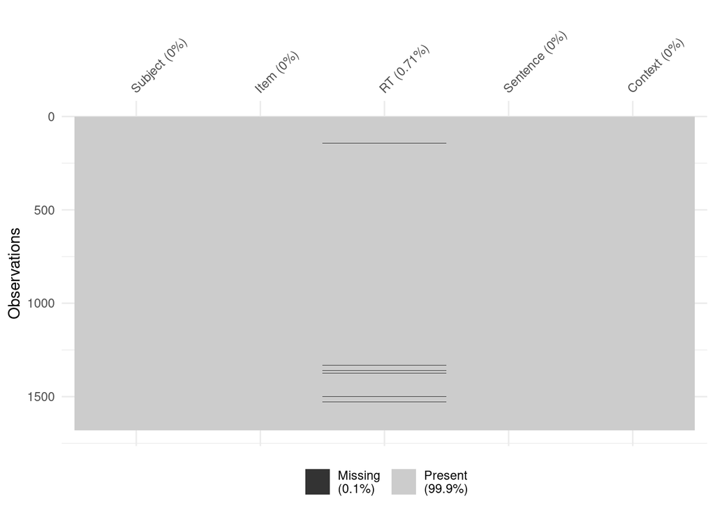

```r
vis_miss(factorial_data_tidied)
```

We can see in the above visualisation that we do indeed have some missing data. We need to tell R what we want it to do with that. We can use the `na.rm = TRUE` parameter to tell it we want missing data to be ignored.

```r
factorial_data_tidied %>%
  group_by(Context, Sentence) %>%
  summarise(mean_rt = mean(RT, na.rm = TRUE), sd_rt = sd(RT, na.rm = TRUE))
```

```
## # A tibble: 4 x 4
## # Groups:   Context [2]
##   Context  Sentence mean_rt sd_rt
##   <fct>    <fct>      <dbl> <dbl>
## 1 Negative Negative   1474.  729.
## 2 Negative Positive   1595.  887.
## 3 Positive Negative   1633.  877.
## 4 Positive Positive   1579.  841.
```

Now we have the summary statistics that we expect.

### Visualising our Data

We can use a modification of the `ggplot()` code we’ve used above to generate our visualisation. Note, I am filtering our the missing data using the `filter()` function before we start our plot. I am also specifying that we’re wanting to plot a combination of our two factors in the `aes()` definition using `Context:Sentence`. There are further things we could modify to improve the look of this graph. Can you figure out ways in which the labelling of the two factors could be clearer?

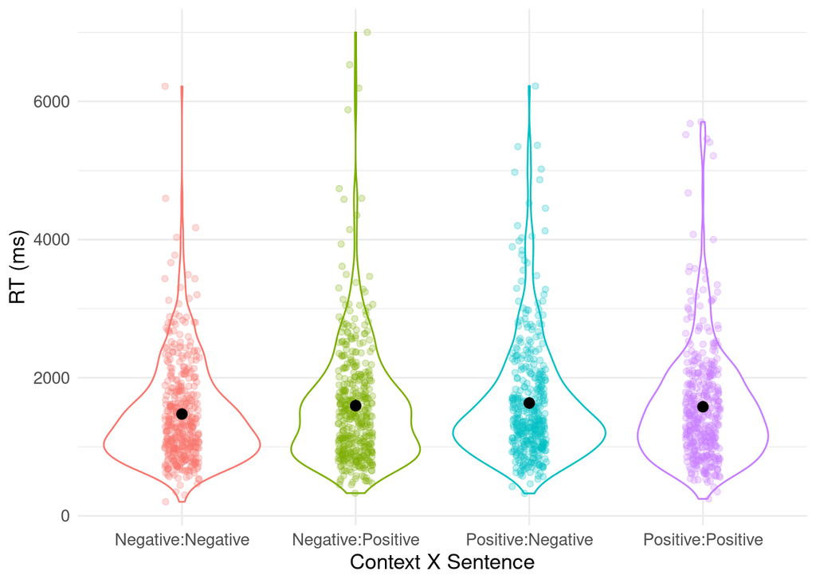

```r
factorial_data_tidied %>%
  filter(!is.na(RT)) %>%
  ggplot(aes(x = Context:Sentence, y = RT, colour = Context:Sentence)) +
  geom_violin() +
  geom_jitter(width = .1, alpha = .25) +
  guides(colour = FALSE) +
  stat_summary(fun.data = "mean_cl_boot", colour = "black") +
  theme_minimal() +
  theme(text = element_text(size = 13)) +
  labs(x = "Context X Sentence", y = "RT (ms)")
```

### Building our ANOVA Model

We have our data in long format where every row is one observation. We haven’t done any data aggregation. The `aov_4()` function will do this for us as ANOVA models need to be built over means (not raw data).

Now we’re going torun a ANOVA for our factorial design treating participants as a random effect using `aov_4()`. The syntax is very similar to what we ran previously, although this time you’ll see we have a new term `Context * Sentence`. This term corresponds to two main effects, plus the interaction between them. It’s shorthand for `Context + Sentence + Context:Sentence`. We also specify this in the random effect By setting `na.rm` to be TRUE, we are telling the analysis to ignore individual trials where there might be missing data - effectively this calculates the condition means over the data that is present (and ignores trials where it is missing).

```r
model_subjects <- aov_4(RT ~ Context * Sentence + (1 + Context * Sentence | Subject), data = factorial_data_tidied, na.rm = TRUE)
```

We can generate the output using the `anova()` function as we did earlier.

```r
anova(model_subjects)
```

```
## Anova Table (Type 3 tests)
##
## Response: RT
##                  num Df den Df    MSE      F       ges  Pr(>F)
## Context               1     59  90195 3.1767 0.0060231 0.07984 .
## Sentence              1     59 124547 0.6283 0.0016524 0.43114
## Context:Sentence      1     59  93889 4.5967 0.0090449 0.03616 *
## ---
## Signif. codes:  0 '***' 0.001 '**' 0.01 '*' 0.05 '.' 0.1 ' ' 1
```

### Interpreting the Model Output

Let’s now interpret our ANOVA where we had participants as our random effect. We will set the error correction adjustment to equal `none` as only some of the comparisons actually make theoretical sense - these are the ones where we’re comparing like with like - Sentences of the same type (Positive *or* Negative) preceded by one version of our Context factor vs. the other.

```r
emmeans(model_subjects, pairwise ~ Context * Sentence, adjust = "none")
```

```
## $emmeans
##  Context  Sentence emmean   SE  df lower.CL upper.CL
##  Negative Negative   1474 57.8 138     1360     1588
##  Positive Negative   1628 57.8 138     1514     1742
##  Negative Positive   1595 57.8 138     1481     1709
##  Positive Positive   1579 57.8 138     1465     1693
##
## Warning: EMMs are biased unless design is perfectly balanced
## Confidence level used: 0.95
##
## $contrasts
##  contrast                              estimate   SE  df t.ratio p.value
##  Negative Negative - Positive Negative   -153.9 55.4 118 -2.779  0.0064
##  Negative Negative - Negative Positive   -120.9 60.3 116 -2.004  0.0474
##  Negative Negative - Positive Positive   -105.2 59.8 115 -1.759  0.0813
##  Positive Negative - Negative Positive     33.0 59.8 115  0.551  0.5824
##  Positive Negative - Positive Positive     48.7 60.3 116  0.807  0.4213
##  Negative Positive - Positive Positive     15.7 55.4 118  0.284  0.7772
```

The key comparisons are the `Negative Negative - Positive Negative` and the `Negative Positive - Positive Positive` ones. In the first case, we are comparing reaction times to Negative Sentences preceded by Negative vs. Positive Contexts, while in the second we are comparing reaction times to Positive Sentences preceded by Negative vs. Positive Contexts. We can manually correct for multiple comparisons (which in this case is 2) by multiplying the corresponding *p*-values by 2 (and putting a limit of 1 on the maximum *p*-value possible). In this case, the first key comparison is sigficant (*p* = .012) while the second is not. We might write up the results like:

We conducted a 2 (Context: Positive vs. Negative) x 2 (Sentence: Positive vs. Negative) repeated measures ANOVA to investigate the influence of Context valence on reaction times to Sentences of Positive or Negative valence. The ANOVA revealed no effect of Sentence (F < 1), no effect of Context (F(1, 59) = 3.18, *p* = .080, ηG2 = .006), but an interaction between Sentence and Context (F(1, 59) = 4.60, *p* = .036, ηG2 = .009).

The interaction was interpreted by conducting Bonferroni-corrected pairwise companions. These comparisons revealed that the interaction was driven by Negative Sentences being processed faster in Negative vs. Positive Contexts (1,474 ms. vs. 1,628 ms., t(118) = 2.78, *p* = .012) while Positive Sentences were read at similar speeds in Negative vs. Positive Contexts (1,595 ms. vs. 1,579 ms., t(118) = .284, *p* = 1).

### Breakout Rooms

I would now like you to work on the following questions in your rooms.

#### Question 1

Our first data file is called `ANOVA_data1.csv` and can be found here:

https://raw.githubusercontent.com/ajstewartlang/11_glm_anova_pt1/master/data/ANOVA_data1.csv

24 participants responded to a word that was either common (i.e., high lexical frequency) or rare (i.e., low lexical frequency). This is our IV and is coded as ‘high’ vs. low’. Our DV is reaction time and is coded as ‘RT’. Subject number is coded as ‘Subject’. We want to know whether there is a difference between conditions (and if so, where that difference lies). Visualise the data, generate descriptives, and run the appropriate ANOVA to determine whether our independent variable (Condition) has an influence on our dependent variable (RT).

#### Question 2

Our second data file is called `ANOVA_data2.csv` and can be found here:

https://raw.githubusercontent.com/ajstewartlang/11_glm_anova_pt1/master/data/ANOVA_data2.csv

These data are also from a reaction time experiment but with a slightly more complex design.48 participants responded to a word that differed in how frequent it was. This factor is between participants and we have four levels coded as ‘very low’, ‘low’, ‘high’, and ‘very high’. Our DV is reaction time and is coded as ‘RT’. Subject number is coded as ‘Subject’. We want to know if there is a difference between our conditions (and if so, where that difference lies).

#### Question 3

Our third data file is called `ANOVA_data3.csv` and can be found here:

https://raw.githubusercontent.com/ajstewartlang/11_glm_anova_pt1/master/data/ANOVA_data3.csv

These data are from a 2 x 2 repeated measures reaction time experiment. We were interested in how quickly participants could respond to images that were Large vs. Small and in Colour vs. Black & White. We expect that Large Colour images will be responded to more quickly than Small B & W images. We’re not sure about Small Colour images and Large B & W images. We measured the response times of 24 participants responding to an image in each of these four conditions. We want to determine if there is a difference between our conditions (and if so, where that difference lies).

#### Question 4

Our fourth data file is called `ANOVA_data4.csv` and can be found here:

https://raw.githubusercontent.com/ajstewartlang/11_glm_anova_pt1/master/data/ANOVA_data4.csv

These data are from a 2 x 2 x 3 mixed design experiment where we measured people’s response times to maths questions that were either Easy or Hard, and to which they had to respond either under Time Pressure or under No Time Pressure. These are our first two factors and are repeated measures (i.e., everyone saw all 4 conditions). Our third factor is between subjects and corresponds to whether our participants were in one of three groups. The groups were Psychology Students, Maths Students, and Arts Students. We want to know where a participant’s perfomance on the maths questions under time pressure vs. not under time pressure is influenced by which one of these three groups they belong to. Conduct the appropriate ANOVA to answer this question. Remember to start off with some data visualisation(s).

### Answers

#### Question 1

The ANOVA should reveal an effect of Condition with F(1, 22) = 91.217. As there are just two levels to our factor, we don’t need to run any follow up tests to know what’s driving the effect. By looking at the descriptive statistics, we see that RT is 865 for our `high` condition and 1178 for our `low` condition.

#### Question 2

The ANOVA should reveal an effect of Condition with F(3, 44) = 203.21. To interpret this further we need to run follow up comparisons. Using the Bonferroni correction these should indicate that every level of Condition differs from every other level.

#### Question 3

The ANOVA should reveal a main effect of Size (F(1, 23) = 198.97), a main effect of Colour (F(1, 23) = 524.27), and an interaction between these two factors (F(1, 23) = 11.08). To interpret this interaction further we need to run follow up comparisons. Using the Bonferroni correction these should indicate that every level of Condition differs from every other level.

#### Question 4

This question is slightly trickier than the ones we’ve looked at so far. After you’ve built your ANOVA (remember to add only your repeated measures factors to your random effect term), you’ll discover a significant 3-way interaction (F(2, 69) = 4.63). You’ll need to break this down further - one possible approach would be to look at the interaction between Difficulty and Time Pressure *separately* for each level of our between group factor. In other words, you’d build one 2 x 2 ANOVA model for each of your Student Groups. If you do this, you’ll see that the 2 x 2 interaction is not significant for the Arts group, nor the Maths group, but the interaction *is* significant for the Psychology group (F(1, 23) = 11.08)) - as too are the two main effects of Difficulty and Time Pressure. But as these two factors interact, the meaning in our data is in the interaction term (not just these two main effects).

So, the 3-way interaction was telling us that the 2-way interaction differed for at least one of our Groups (relative to the other Groups). We need to examine this 2-way interaction further for our Psychology group by conducting pairwise comparisons, exactly as you’ve done above. This will reveal that for our Psychology group, each condition differs significantly from the other conditions. It means that for Psychology students, the Hard problems take long under Time Pressure vs. under No Time Pressure, and the Easy problems take longer under Time Pressure vs. under No Time Pressure (but neither of these are as long as for Hard problems).